# Research Agenda

Zach Dickson

London School of Economics

# Research Agenda

*Three key themes*

- **The rise of right-wing populism**
  - Cultural drivers of support
  - Inequality – spatial and distributional effects
- **Climate Change politics and policy**
  - Distributional consequences of climate change policies
  - How do we get voters to accept costly climate policies?
- **Political communication and social media**
  - The effects of political communication on public opinion/behaviour
  - Social media, political extremism and gender backlash

## Climate Change and Environmental Politics

**Working Projects:**

1. *Energy Prices and Policy Support* (recently funded by British Academy)
2. *Benchmarking Support for the EU Green Deal* (funded by Volkswagen Foundation)
3. *Civic education on Climate Change: A coordinated solution for a coordinated problem?* (funded by Volkswagen Foundation)

**Publications:**

1. [Going against the grain: Climate change as a wedge issue for the radical right](https://doi.org/10.1177/0010414024127129)
- *Quote:* The radical right increasingly uses climate change policy as a wedge issue to divide existing coalitions and attract climate-sceptic voters

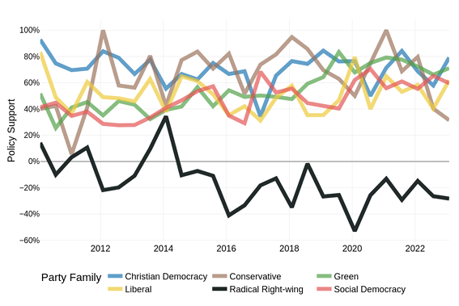

## Right-wing Populism

**Working Projects:** 1. *Public Service Decline and Support for the Populist Right* (funded by ERC) 2. *Normalising the Radical Right? The 2024 UK Race Riots* 3. *Inequality and Support for Right-wing Populism in Britain*

**Publications:**

1. [Elite Cues and Noncompliance](https://doi.org/10.1017/S0003055424000741)
1. *Quote:* Despite whether Donald Trump means what he says, his supporters take him seriously and will act on his demands
2. [The effects of COVID-19 infection on opposition to COVID-19 policies: evidence from the US congress](https://doi.org/10.1080/10584609.2024.2364072)
1. *Quote:* US congressmemebers will update their beliefs in response to personal implications
3. [The youth gender gap in support for the far right](https://doi.org/10.1080/13501763.2025.2481181)
1. *Quote:* There is a bigger gender gap among younger voters in support for the radical right than in previous decades.